# House price prediction - Advanced

```python
import numpy as np
import pandas as pd
import seaborn as sns
import matplotlib.pyplot as plt

%matplotlib inline
pd.pandas.set_option('display.max_columns',None)
```

```python
train_data = pd.read_csv("train.csv")
test_data = pd.read_csv("test.csv")
```

```python
train_data.shape,test_data.shape
```

```
((1460, 81), (1459, 80))
```

```python
train_data
```

|  | Id | MSSubClass | MSZoning | LotFrontage | LotArea | Street | Alley | LotShape | LandContour | Utilities | ... | PoolArea | PoolQC | Fence | MiscFeature | MiscVal | MoSold | YrSold | SaleType | SaleCondition | SalePrice |
| --- | --- | --- | --- | --- | --- | --- | --- | --- | --- | --- | --- | --- | --- | --- | --- | --- | --- | --- | --- | --- | --- |
| 0 | 1 | 60 | RL | 65.0 | 8450 | Pave | NaN | Reg | Lvl | AllPub | ... | 0 | NaN | NaN | NaN | 0 | 2 | 2008 | WD | Normal | 208500 |
| 1 | 2 | 20 | RL | 80.0 | 9600 | Pave | NaN | Reg | Lvl | AllPub | ... | 0 | NaN | NaN | NaN | 0 | 5 | 2007 | WD | Normal | 181500 |
| 2 | 3 | 60 | RL | 68.0 | 11250 | Pave | NaN | IR1 | Lvl | AllPub | ... | 0 | NaN | NaN | NaN | 0 | 9 | 2008 | WD | Normal | 223500 |
| 3 | 4 | 70 | RL | 60.0 | 9550 | Pave | NaN | IR1 | Lvl | AllPub | ... | 0 | NaN | NaN | NaN | 0 | 2 | 2006 | WD | Abnorml | 140000 |
| 4 | 5 | 60 | RL | 84.0 | 14260 | Pave | NaN | IR1 | Lvl | AllPub | ... | 0 | NaN | NaN | NaN | 0 | 12 | 2008 | WD | Normal | 250000 |
| ... | ... | ... | ... | ... | ... | ... | ... | ... | ... | ... | ... | ... | ... | ... | ... | ... | ... | ... | ... | ... | ... |
| 1455 | 1456 | 60 | RL | 62.0 | 7917 | Pave | NaN | Reg | Lvl | AllPub | ... | 0 | NaN | NaN | NaN | 0 | 8 | 2007 | WD | Normal | 175000 |
| 1456 | 1457 | 20 | RL | 85.0 | 13175 | Pave | NaN | Reg | Lvl | AllPub | ... | 0 | NaN | MnPrv | NaN | 0 | 2 | 2010 | WD | Normal | 210000 |
| 1457 | 1458 | 70 | RL | 66.0 | 9042 | Pave | NaN | Reg | Lvl | AllPub | ... | 0 | NaN | GdPrv | Shed | 2500 | 5 | 2010 | WD | Normal | 266500 |
| 1458 | 1459 | 20 | RL | 68.0 | 9717 | Pave | NaN | Reg | Lvl | AllPub | ... | 0 | NaN | NaN | NaN | 0 | 4 | 2010 | WD | Normal | 142125 |
| 1459 | 1460 | 20 | RL | 75.0 | 9937 | Pave | NaN | Reg | Lvl | AllPub | ... | 0 | NaN | NaN | NaN | 0 | 6 | 2008 | WD | Normal | 147500 |

1460 rows × 81 columns

# Exploratory data analysis

1) Missing values

```python
#Checking which of the features has null values

featuresNa = [feature for feature in train_data.columns if train_data[feature].isnull().sum()>=1]

print(len(featuresNa))

for feature in featuresNa:
    print("'{}' of type {} has {} % of null values\n".format(feature ,train_data[feature].dtypes, np.round(train_data[feature].isnull().mean(),3)))
```

```
19
'LotFrontage' of type float64 has 0.177 % of null values

'Alley' of type object has 0.938 % of null values

'MasVnrType' of type object has 0.005 % of null values

'MasVnrArea' of type float64 has 0.005 % of null values

'BsmtQual' of type object has 0.025 % of null values

'BsmtCond' of type object has 0.025 % of null values

'BsmtExposure' of type object has 0.026 % of null values

'BsmtFinType1' of type object has 0.025 % of null values

'BsmtFinType2' of type object has 0.026 % of null values

'Electrical' of type object has 0.001 % of null values

'FireplaceQu' of type object has 0.473 % of null values

'GarageType' of type object has 0.055 % of null values

'GarageYrBlt' of type float64 has 0.055 % of null values

'GarageFinish' of type object has 0.055 % of null values

'GarageQual' of type object has 0.055 % of null values

'GarageCond' of type object has 0.055 % of null values

'PoolQC' of type object has 0.995 % of null values

'Fence' of type object has 0.808 % of null values

'MiscFeature' of type object has 0.963 % of null values
```

There exists lot of features with null values, now lets check whether the null values has any effect on the target ('Sales Price')

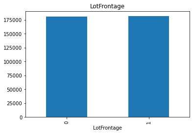

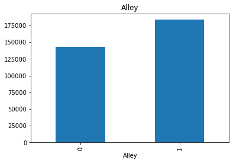

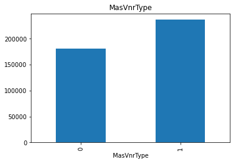

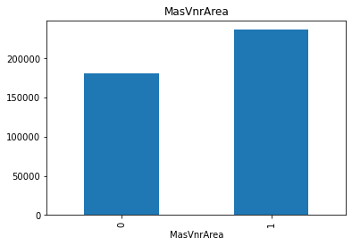

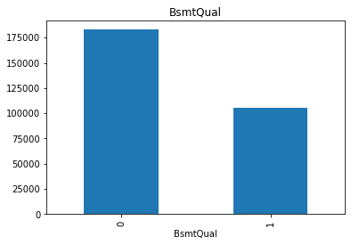

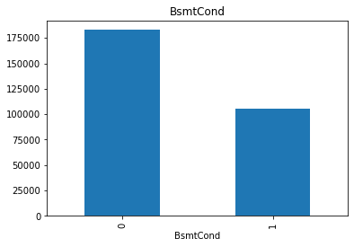

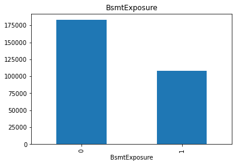

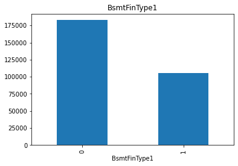

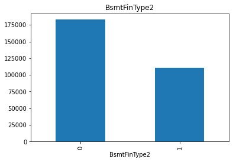

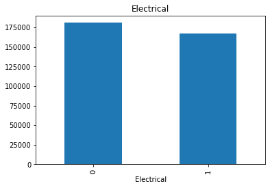

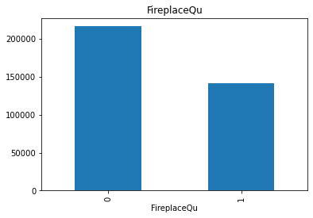

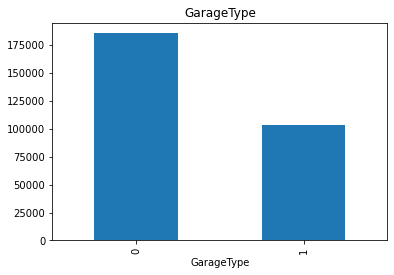

[7 more figures not shown]

```python
for feature in featuresNa:
    data = train_data.copy()

    data[feature] = np.where(data[feature].isnull(), 1, 0)

    data.groupby(feature)['SalePrice'].mean().plot.bar()
    plt.title(feature)
    plt.show()
```

From the above plots, It became evident that the missing_values has some impact on the target ('Sales Price') ... Now let's decode the numerical variables

```python
#Fetching the columns with numerical values

numerical_columns = [feature for feature in train_data.columns if train_data[feature].dtypes != 'O']
print(len(numerical_columns))
numerical_columns
```

```
38
```

```
['Id',
 'MSSubClass',
 'LotFrontage',
 'LotArea',
 'OverallQual',
 'OverallCond',
 'YearBuilt',
 'YearRemodAdd',
 'MasVnrArea',
 'BsmtFinSF1',
 'BsmtFinSF2',
 'BsmtUnfSF',
 'TotalBsmtSF',
 '1stFlrSF',
 '2ndFlrSF',
 'LowQualFinSF',
 'GrLivArea',
 'BsmtFullBath',
 'BsmtHalfBath',
 'FullBath',
 'HalfBath',
 'BedroomAbvGr',
 'KitchenAbvGr',
 'TotRmsAbvGrd',
 'Fireplaces',
 'GarageYrBlt',
 'GarageCars',
 'GarageArea',
 'WoodDeckSF',
 'OpenPorchSF',
 'EnclosedPorch',
 '3SsnPorch',
 'ScreenPorch',
 'PoolArea',
 'MiscVal',
 'MoSold',
 'YrSold',
 'SalePrice']
```

There are some datetime based variables (Year) in numerical category lets see how they impact the target

```python
datetime_columns = [feature for feature in numerical_columns if 'Year' in feature or 'Yr' in feature]

datetime_columns
```

```
['YearBuilt', 'YearRemodAdd', 'GarageYrBlt', 'YrSold']
```

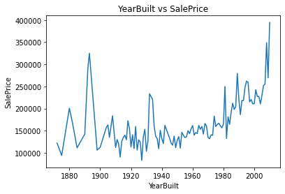

```python
#Lets see the feature yearbuilt's relation with SalePrice

train_data.groupby("YearBuilt")['SalePrice'].mean().plot()
plt.ylabel("SalePrice")
plt.title("YearBuilt vs SalePrice" , size = 12)
```

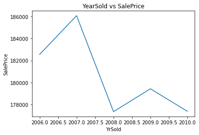

```python
#Lets see the feature yearsold's relation with SalePrice

train_data.groupby("YrSold")['SalePrice'].mean().plot()
plt.ylabel("SalePrice")
plt.title("YearSold vs SalePrice" , size = 12)
```

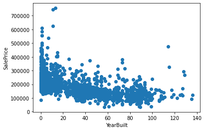

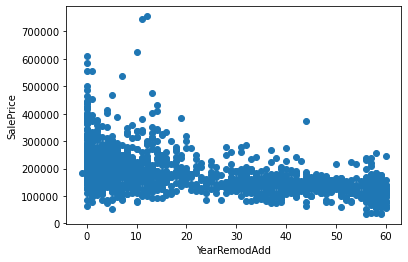

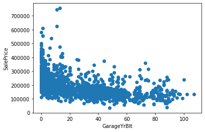

```python
for feature in datetime_columns:
    if feature != 'YrSold':
        data = train_data.copy()
        data[feature]=data['YrSold']-data[feature]
        plt.scatter(data[feature],data["SalePrice"])
        plt.xlabel(feature)
        plt.ylabel("SalePrice")
        plt.show()
```

From the above plots it is evident that, new houses are sold for higher prices than old ones and the houses sold immediately after modification of extension got higher prices

```python
#Lets split the numerical feature further into discrete and continuous with a threshold of 20

discrete_columns = [feature for feature in numerical_columns if len(train_data[feature].unique()) < 20
                                                                 and feature not in datetime_columns + ['Id']]
print(len(discrete_columns))
discrete_columns
```

```
14
```

```
['MSSubClass',
 'OverallQual',
 'OverallCond',
 'BsmtFullBath',
 'BsmtHalfBath',
 'FullBath',
 'HalfBath',
 'BedroomAbvGr',
 'KitchenAbvGr',
 'TotRmsAbvGrd',
 'Fireplaces',
 'GarageCars',
 'PoolArea',
 'MoSold']
```

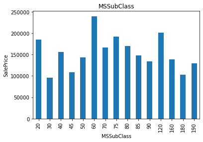

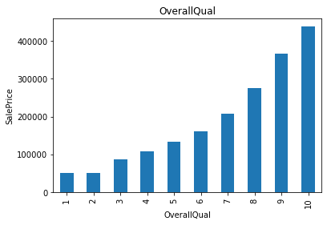

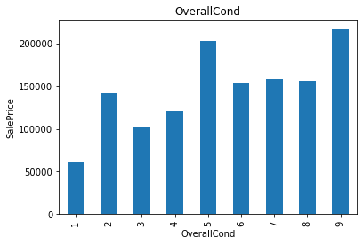

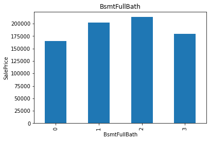

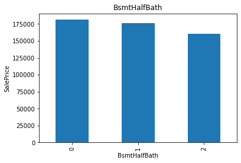

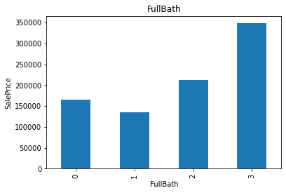

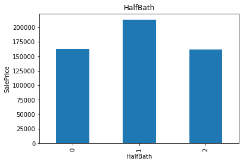

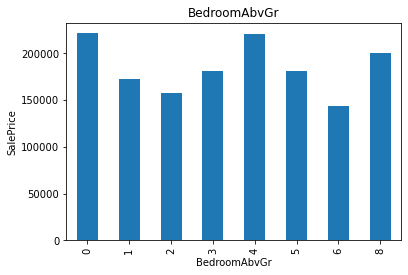

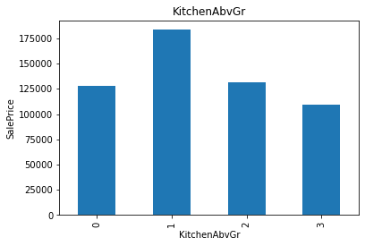

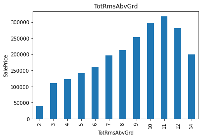

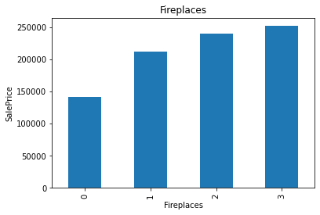

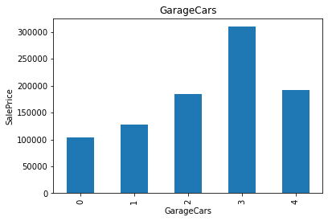

[2 more figures not shown]

```python
#Relationship between discrete variables and SalePrice

for feature in discrete_columns:
    data=train_data.copy()
    data.groupby(feature)['SalePrice'].mean().plot.bar()
    plt.xlabel(feature)
    plt.ylabel('SalePrice')
    plt.title(feature)
    plt.show()
```

From the above visualizations it is clear that each discrete variable show some significant impact towards the target. Especially as the feature 'OverallQual' increases the 'SalePrice rises functionally. Now, Let's get into continuous variables

```python
continuous_columns = [feature for feature in numerical_columns if(feature not in discrete_columns+datetime_columns+['Id'])]

print(len(continuous_columns))
continuous_columns
```

```
19
```

```
['LotFrontage',
 'LotArea',
 'MasVnrArea',
 'BsmtFinSF1',
 'BsmtFinSF2',
 'BsmtUnfSF',
 'TotalBsmtSF',
 '1stFlrSF',
 '2ndFlrSF',
 'LowQualFinSF',
 'GrLivArea',
 'GarageArea',
 'WoodDeckSF',
 'OpenPorchSF',
 'EnclosedPorch',
 '3SsnPorch',
 'ScreenPorch',
 'MiscVal',
 'SalePrice']
```

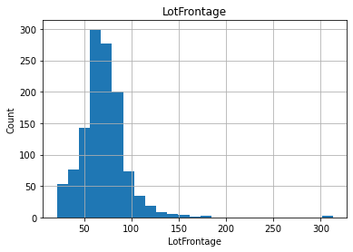

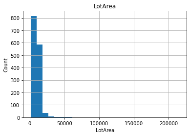

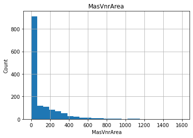

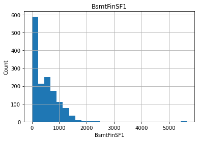

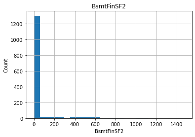

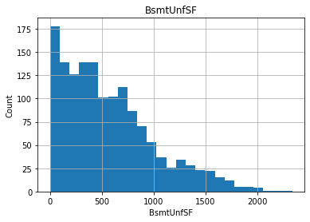

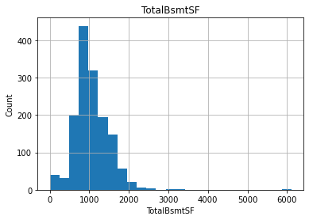

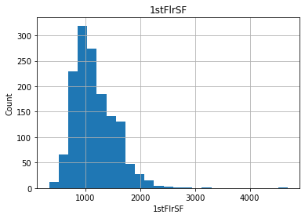

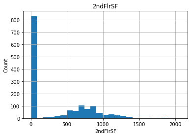

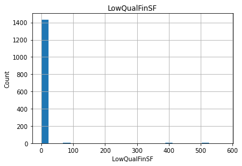

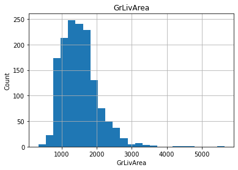

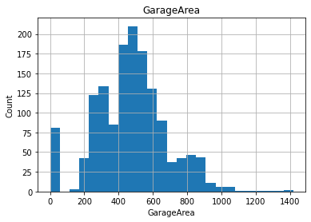

[7 more figures not shown]

```python
#Lets understand the distribution of continuous variable features in using histograms

for feature in continuous_columns:
    data=train_data.copy()
    data[feature].hist(bins=25)
    plt.xlabel(feature)
    plt.ylabel("Count")
    plt.title(feature)
    plt.show()
```

From the above visualizations it is evident that except 'SalePrice' other features are not normally distributed. Since in regression problems, the data distribution being normally distributed improves the performance and helps gradient descent converge faster, lets make the possible features 'log normally' distributed

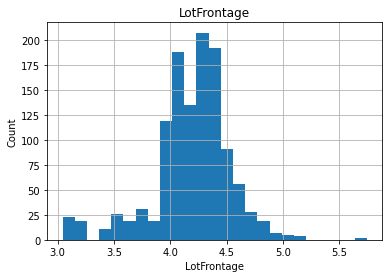

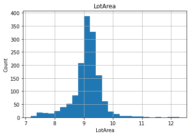

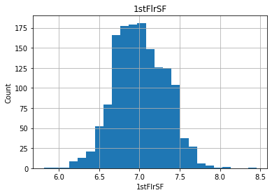

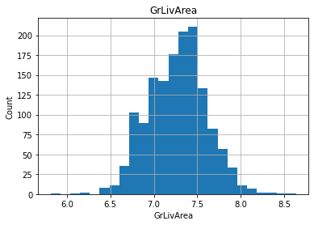

```python
#Conversion from random to log normal distribution on possible features

for feature in continuous_columns:
    if feature != 'SalePrice':
        data=train_data.copy()
        data['SalePrice']=np.log(data['SalePrice'])
        if 0 in data[feature].unique():   #Since log(0) is infinite we cant apply log normalalization to the features with '0' in it!
            pass
        else:
            data[feature]=np.log(data[feature])
            data['SalePrice']=np.log(data['SalePrice'])
            data[feature].hist(bins=25)
            plt.xlabel(feature)
            plt.ylabel("Count")
            plt.title(feature)
            plt.show()
```

Now, Let's work on categorical variables

```python
categorical_columns = [feature for feature in train_data.columns if(train_data[feature].dtypes == 'O')]

print(len(categorical_columns))
categorical_columns
```

```
43
```

```
['MSZoning',
 'Street',
 'Alley',
 'LotShape',
 'LandContour',
 'Utilities',
 'LotConfig',
 'LandSlope',
 'Neighborhood',
 'Condition1',
 'Condition2',
 'BldgType',
 'HouseStyle',
 'RoofStyle',
 'RoofMatl',
 'Exterior1st',
 'Exterior2nd',
 'MasVnrType',
 'ExterQual',
 'ExterCond',
 'Foundation',
 'BsmtQual',
 'BsmtCond',
 'BsmtExposure',
 'BsmtFinType1',
 'BsmtFinType2',
 'Heating',
 'HeatingQC',
 'CentralAir',
 'Electrical',
 'KitchenQual',
 'Functional',
 'FireplaceQu',
 'GarageType',
 'GarageFinish',
 'GarageQual',
 'GarageCond',
 'PavedDrive',
 'PoolQC',
 'Fence',
 'MiscFeature',
 'SaleType',
 'SaleCondition']
```

```python
#Lets see the number of categories in each of the categorical features

for feature in categorical_columns:
    print("{} has {} categories".format(feature,len(train_data[feature].unique())))
```

```
MSZoning has 5 categories
Street has 2 categories
Alley has 3 categories
LotShape has 4 categories
LandContour has 4 categories
Utilities has 2 categories
LotConfig has 5 categories
LandSlope has 3 categories
Neighborhood has 25 categories
Condition1 has 9 categories
Condition2 has 8 categories
BldgType has 5 categories
HouseStyle has 8 categories
RoofStyle has 6 categories
RoofMatl has 8 categories
Exterior1st has 15 categories
Exterior2nd has 16 categories
MasVnrType has 5 categories
ExterQual has 4 categories
ExterCond has 5 categories
Foundation has 6 categories
BsmtQual has 5 categories
BsmtCond has 5 categories
BsmtExposure has 5 categories
BsmtFinType1 has 7 categories
BsmtFinType2 has 7 categories
Heating has 6 categories
HeatingQC has 5 categories
CentralAir has 2 categories
Electrical has 6 categories
KitchenQual has 4 categories
Functional has 7 categories
FireplaceQu has 6 categories
GarageType has 7 categories
GarageFinish has 4 categories
GarageQual has 6 categories
GarageCond has 6 categories
PavedDrive has 3 categories
PoolQC has 4 categories
Fence has 5 categories
MiscFeature has 5 categories
SaleType has 9 categories
SaleCondition has 6 categories
```

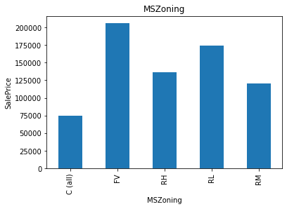

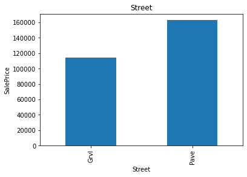

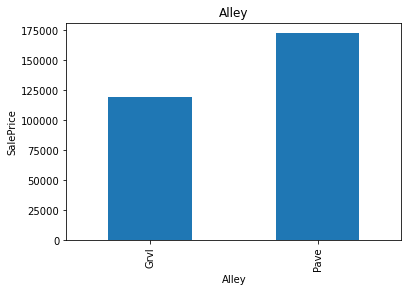

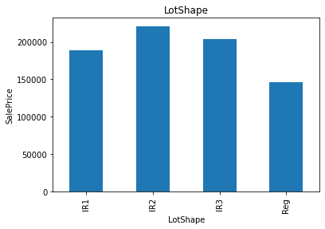

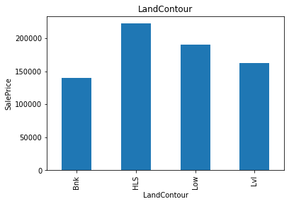

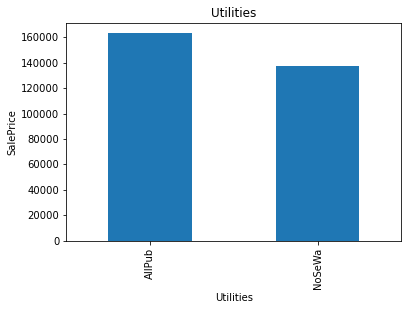

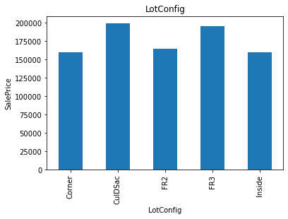

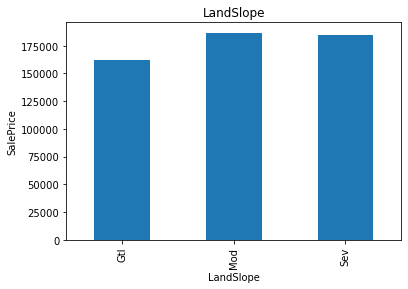

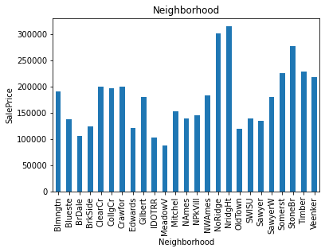

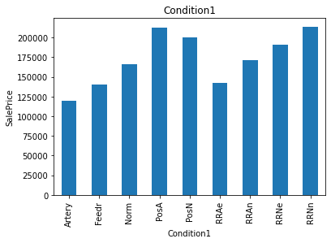

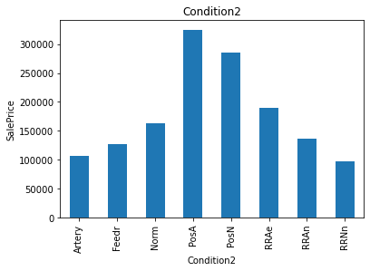

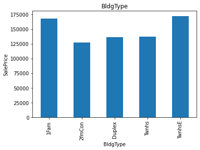

[31 more figures not shown]

```python
#Relationship between categorical variables and the target 'SalePrice'

for feature in categorical_columns:
    data=train_data.copy()
    data.groupby(feature)['SalePrice'].median().plot.bar()
    plt.xlabel(feature)
    plt.ylabel('SalePrice')
    plt.title(feature)
    plt.show()
```

# Feature Engineering

Handling null values

```python
#Handling categorical null values

categoricalNa = [feature for feature in featuresNa if(train_data[feature].dtypes == 'O')]

for feature in categoricalNa:
    train_data[categoricalNa] = train_data[categoricalNa].fillna('wanted')

train_data[categoricalNa].isnull().sum()
```

```
Alley           0
MasVnrType      0
BsmtQual        0
BsmtCond        0
BsmtExposure    0
BsmtFinType1    0
BsmtFinType2    0
Electrical      0
FireplaceQu     0
GarageType      0
GarageFinish    0
GarageQual      0
GarageCond      0
PoolQC          0
Fence           0
MiscFeature     0
dtype: int64
```

```python
#Handling discrete numeric null values(Actually there's no null value in this set)

discreteNa = [feature for feature in featuresNa if feature in discrete_columns]

for feature in discreteNa:
    # Adding a new binary feature, 0 - was not null 1 - was null
    train_data[feature+'Na'] = np.where(train_data[feature].isnull(),1,0)
    # Filling null values with mode as the features are discrete numeric
    train_data[feature] = train_data[feature].fillna(train_data[feature].mode())

train_data[discreteNa].isnull().sum()
```

```
Series([], dtype: float64)
```

```python
#Handling continuous numeric null values

# Used 'numerical_columns' because 'GarageYrBlt' has been seperated in continuous_columns
continuousNa = [feature for feature in featuresNa if feature in numerical_columns]

for feature in continuousNa:
    # Adding a new binary feature, 0 - was not null 1 - was null
    train_data[feature+'Na'] = np.where(train_data[feature].isnull(),1,0)
    # Filling null values with median as there are many outliers in the continuous numerical features
    train_data[feature] = train_data[feature].fillna(train_data[feature].median())

train_data[continuousNa].isnull().sum()
```

```
LotFrontage    0
MasVnrArea     0
GarageYrBlt    0
dtype: int64
```

```python
#Updating the datetime feature columns

for feature in datetime_columns:
    if feature != 'YrSold':
        #Since the difference from yearsold yielded much more information related to the logic of the target prediction
        train_data[feature] = train_data['YrSold'] - train_data[feature]
```

```python
train_data.head()
```

|  | Id | MSSubClass | MSZoning | LotFrontage | LotArea | Street | Alley | LotShape | LandContour | Utilities | LotConfig | LandSlope | Neighborhood | Condition1 | Condition2 | BldgType | HouseStyle | OverallQual | OverallCond | YearBuilt | YearRemodAdd | RoofStyle | RoofMatl | Exterior1st | Exterior2nd | MasVnrType | MasVnrArea | ExterQual | ExterCond | … |
| --- | --- | --- | --- | --- | --- | --- | --- | --- | --- | --- | --- | --- | --- | --- | --- | --- | --- | --- | --- | --- | --- | --- | --- | --- | --- | --- | --- | --- | --- | --- |
| 0 | 1 | 60 | RL | 65.0 | 8450 | Pave | wanted | Reg | Lvl | AllPub | Inside | Gtl | CollgCr | Norm | Norm | 1Fam | 2Story | 7 | 5 | 5 | 5 | Gable | CompShg | VinylSd | VinylSd | BrkFace | 196.0 | Gd | TA | … |
| 1 | 2 | 20 | RL | 80.0 | 9600 | Pave | wanted | Reg | Lvl | AllPub | FR2 | Gtl | Veenker | Feedr | Norm | 1Fam | 1Story | 6 | 8 | 31 | 31 | Gable | CompShg | MetalSd | MetalSd | None | 0.0 | TA | TA | … |
| 2 | 3 | 60 | RL | 68.0 | 11250 | Pave | wanted | IR1 | Lvl | AllPub | Inside | Gtl | CollgCr | Norm | Norm | 1Fam | 2Story | 7 | 5 | 7 | 6 | Gable | CompShg | VinylSd | VinylSd | BrkFace | 162.0 | Gd | TA | … |
| 3 | 4 | 70 | RL | 60.0 | 9550 | Pave | wanted | IR1 | Lvl | AllPub | Corner | Gtl | Crawfor | Norm | Norm | 1Fam | 2Story | 7 | 5 | 91 | 36 | Gable | CompShg | Wd Sdng | Wd Shng | None | 0.0 | TA | TA | … |
| 4 | 5 | 60 | RL | 84.0 | 14260 | Pave | wanted | IR1 | Lvl | AllPub | FR2 | Gtl | NoRidge | Norm | Norm | 1Fam | 2Story | 8 | 5 | 8 | 8 | Gable | CompShg | VinylSd | VinylSd | BrkFace | 350.0 | Gd | TA | … |

```python
#Log normalizing possible numerical features

possible_features = ['LotFrontage','LotArea','1stFlrSF','GrLivArea']

for feature in possible_features:
    train_data[feature] = np.log(train_data[feature])

train_data.head()
```

|  | Id | MSSubClass | MSZoning | LotFrontage | LotArea | Street | Alley | LotShape | LandContour | Utilities | LotConfig | LandSlope | Neighborhood | Condition1 | Condition2 | BldgType | HouseStyle | OverallQual | OverallCond | YearBuilt | YearRemodAdd | RoofStyle | RoofMatl | Exterior1st | Exterior2nd | MasVnrType | MasVnrArea | ExterQual | ExterCond | … |
| --- | --- | --- | --- | --- | --- | --- | --- | --- | --- | --- | --- | --- | --- | --- | --- | --- | --- | --- | --- | --- | --- | --- | --- | --- | --- | --- | --- | --- | --- | --- |
| 0 | 1 | 60 | RL | 4.174387 | 9.041922 | Pave | wanted | Reg | Lvl | AllPub | Inside | Gtl | CollgCr | Norm | Norm | 1Fam | 2Story | 7 | 5 | 5 | 5 | Gable | CompShg | VinylSd | VinylSd | BrkFace | 196.0 | Gd | TA | … |
| 1 | 2 | 20 | RL | 4.382027 | 9.169518 | Pave | wanted | Reg | Lvl | AllPub | FR2 | Gtl | Veenker | Feedr | Norm | 1Fam | 1Story | 6 | 8 | 31 | 31 | Gable | CompShg | MetalSd | MetalSd | None | 0.0 | TA | TA | … |
| 2 | 3 | 60 | RL | 4.219508 | 9.328123 | Pave | wanted | IR1 | Lvl | AllPub | Inside | Gtl | CollgCr | Norm | Norm | 1Fam | 2Story | 7 | 5 | 7 | 6 | Gable | CompShg | VinylSd | VinylSd | BrkFace | 162.0 | Gd | TA | … |
| 3 | 4 | 70 | RL | 4.094345 | 9.164296 | Pave | wanted | IR1 | Lvl | AllPub | Corner | Gtl | Crawfor | Norm | Norm | 1Fam | 2Story | 7 | 5 | 91 | 36 | Gable | CompShg | Wd Sdng | Wd Shng | None | 0.0 | TA | TA | … |
| 4 | 5 | 60 | RL | 4.430817 | 9.565214 | Pave | wanted | IR1 | Lvl | AllPub | FR2 | Gtl | NoRidge | Norm | Norm | 1Fam | 2Story | 8 | 5 | 8 | 8 | Gable | CompShg | VinylSd | VinylSd | BrkFace | 350.0 | Gd | TA | … |

```python
#Encoding the categorical features with higher values for those categories in which SalesPrice is high

for feature in categorical_columns:
    order = train_data.groupby([feature])['SalePrice'].mean().sort_values().index
    ordered_dict={k:i for i,k in enumerate(order,0)}
    train_data[feature]=train_data[feature].map(ordered_dict)
train_data.head()
```

|  | Id | MSSubClass | MSZoning | LotFrontage | LotArea | Street | Alley | LotShape | LandContour | Utilities | LotConfig | LandSlope | Neighborhood | Condition1 | Condition2 | BldgType | HouseStyle | OverallQual | OverallCond | YearBuilt | YearRemodAdd | RoofStyle | RoofMatl | Exterior1st | Exterior2nd | MasVnrType | MasVnrArea | ExterQual | ExterCond | … |
| --- | --- | --- | --- | --- | --- | --- | --- | --- | --- | --- | --- | --- | --- | --- | --- | --- | --- | --- | --- | --- | --- | --- | --- | --- | --- | --- | --- | --- | --- | --- |
| 0 | 1 | 60 | 3 | 4.174387 | 9.041922 | 1 | 2 | 0 | 1 | 1 | 0 | 0 | 16 | 4 | 4 | 4 | 6 | 7 | 5 | 5 | 5 | 1 | 2 | 11 | 12 | 2 | 196.0 | 2 | 3 | … |
| 1 | 2 | 20 | 3 | 4.382027 | 9.169518 | 1 | 2 | 0 | 1 | 1 | 1 | 0 | 20 | 2 | 4 | 4 | 5 | 6 | 8 | 31 | 31 | 1 | 2 | 4 | 5 | 1 | 0.0 | 1 | 3 | … |
| 2 | 3 | 60 | 3 | 4.219508 | 9.328123 | 1 | 2 | 1 | 1 | 1 | 0 | 0 | 16 | 4 | 4 | 4 | 6 | 7 | 5 | 7 | 6 | 1 | 2 | 11 | 12 | 2 | 162.0 | 2 | 3 | … |
| 3 | 4 | 70 | 3 | 4.094345 | 9.164296 | 1 | 2 | 1 | 1 | 1 | 2 | 0 | 17 | 4 | 4 | 4 | 6 | 7 | 5 | 91 | 36 | 1 | 2 | 5 | 8 | 1 | 0.0 | 1 | 3 | … |
| 4 | 5 | 60 | 3 | 4.430817 | 9.565214 | 1 | 2 | 1 | 1 | 1 | 1 | 0 | 24 | 4 | 4 | 4 | 6 | 8 | 5 | 8 | 8 | 1 | 2 | 11 | 12 | 2 | 350.0 | 2 | 3 | … |

```python
#Cell to save the preprocessed train_data for further use

train_data.to_csv('train_data_preprocessed.csv',index=False)
```

```python
#Feature scaling

#Dropping id and seperating our dependant variable 'SalePrice' before doing feature scaling

y = train_data['SalePrice']
train_data = train_data.drop(['Id','SalePrice'],axis = 1)

from sklearn.preprocessing import MinMaxScaler

features_to_scale = [feature for feature in train_data.columns if feature not in ['Id','SalePrice']]

normalizer = MinMaxScaler()
train_data = pd.DataFrame(normalizer.fit_transform(train_data[features_to_scale]),columns = [features_to_scale])

train_data.head()
```

|  | MSSubClass | MSZoning | LotFrontage | LotArea | Street | Alley | LotShape | LandContour | Utilities | LotConfig | LandSlope | Neighborhood | Condition1 | Condition2 | BldgType | HouseStyle | OverallQual | OverallCond | YearBuilt | YearRemodAdd | RoofStyle | RoofMatl | Exterior1st | Exterior2nd | MasVnrType | MasVnrArea | ExterQual | ExterCond | Foundation | … |
| --- | --- | --- | --- | --- | --- | --- | --- | --- | --- | --- | --- | --- | --- | --- | --- | --- | --- | --- | --- | --- | --- | --- | --- | --- | --- | --- | --- | --- | --- | --- |
| 0 | 0.235294 | 0.75 | 0.418208 | 0.366344 | 1.0 | 1.0 | 0.000000 | 0.333333 | 1.0 | 0.00 | 0.0 | 0.666667 | 0.50 | 0.571429 | 1.0 | 0.857143 | 0.666667 | 0.500 | 0.036765 | 0.098361 | 0.2 | 0.285714 | 0.785714 | 0.800000 | 0.50 | 0.12250 | 0.666667 | 0.75 | 1.0 | … |
| 1 | 0.000000 | 0.75 | 0.495064 | 0.391317 | 1.0 | 1.0 | 0.000000 | 0.333333 | 1.0 | 0.25 | 0.0 | 0.833333 | 0.25 | 0.571429 | 1.0 | 0.714286 | 0.555556 | 0.875 | 0.227941 | 0.524590 | 0.2 | 0.285714 | 0.285714 | 0.333333 | 0.25 | 0.00000 | 0.333333 | 0.75 | 0.4 | … |
| 2 | 0.235294 | 0.75 | 0.434909 | 0.422359 | 1.0 | 1.0 | 0.333333 | 0.333333 | 1.0 | 0.00 | 0.0 | 0.666667 | 0.50 | 0.571429 | 1.0 | 0.857143 | 0.666667 | 0.500 | 0.051471 | 0.114754 | 0.2 | 0.285714 | 0.785714 | 0.800000 | 0.50 | 0.10125 | 0.666667 | 0.75 | 1.0 | … |
| 3 | 0.294118 | 0.75 | 0.388581 | 0.390295 | 1.0 | 1.0 | 0.333333 | 0.333333 | 1.0 | 0.50 | 0.0 | 0.708333 | 0.50 | 0.571429 | 1.0 | 0.857143 | 0.666667 | 0.500 | 0.669118 | 0.606557 | 0.2 | 0.285714 | 0.357143 | 0.533333 | 0.25 | 0.00000 | 0.333333 | 0.75 | 0.2 | … |
| 4 | 0.235294 | 0.75 | 0.513123 | 0.468761 | 1.0 | 1.0 | 0.333333 | 0.333333 | 1.0 | 0.25 | 0.0 | 1.000000 | 0.50 | 0.571429 | 1.0 | 0.857143 | 0.777778 | 0.500 | 0.058824 | 0.147541 | 0.2 | 0.285714 | 0.785714 | 0.800000 | 0.50 | 0.21875 | 0.666667 | 0.75 | 1.0 | … |

```python
train_data.shape,len(y)
```

```
((1460, 82), 1460)
```

```python
#Cell to split train_data into model train and test data

from sklearn.model_selection import train_test_split

x_train,x_test,y_train,y_test = train_test_split(train_data,y,test_size = 0.10,random_state = 42)
```

```python
x_train.shape,y_train.shape
```

```
((1314, 82), (1314,))
```

```python
x_test.shape,y_test.shape
```

```
((146, 82), (146,))
```

# Model Selection

Linear regression

```python
from sklearn.linear_model import LinearRegression

lreg = LinearRegression()
lreg.fit(x_train,y_train)
```

```
LinearRegression()
```

```python
lreg.score(x_train,y_train),lreg.score(x_test,y_test)
```

```
(0.8583395057826577, 0.8556279142034198)
```

Lasso regression

```python
from sklearn import linear_model

clf = linear_model.Lasso(alpha=0.1)

clf.fit(x_train,y_train)
```

```
Lasso(alpha=0.1)
```

```python
clf.score(x_train,y_train),clf.score(x_test,y_test)
```

```
(0.8583385715124714, 0.8557451559368618)
```

Support Vector Regressor (SVR)

```python
#Linear Kernel

from sklearn.svm import SVR

svr_lin = SVR(kernel='linear', C=60000, gamma='auto')

svr_lin.fit(x_train, y_train)
```

```
SVR(C=60000, gamma='auto', kernel='linear')
```

```python
svr_lin.score(x_train, y_train),svr_lin.score(x_train, y_train)
```

```
(0.8309381578929587, 0.8309381578929587)
```

```python
# Rbf kernel

svr_rbf = SVR(kernel='rbf', C=10000, gamma=0.09, epsilon=.1)

svr_rbf.fit(x_train, y_train)
```

```
SVR(C=10000, gamma=0.09)
```

```python
svr_rbf.score(x_train, y_train),svr_rbf.score(x_train, y_train)
```

```
(0.8033700023235208, 0.8033700023235208)
```

```python
#Polynomial kernel

svr_poly = SVR(kernel='poly', C=100000, gamma='auto', degree=2, epsilon=.2,coef0=1)

svr_poly.fit(x_train, y_train)
```

```
SVR(C=100000, coef0=1, degree=2, epsilon=0.2, gamma='auto', kernel='poly')
```

```python
svr_poly.score(x_train, y_train),svr_poly.score(x_train, y_train)
```

```
(0.8283537851051596, 0.8283537851051596)
```

XGBoost Regressor

```python
from xgboost import XGBRegressor

xgb = XGBRegressor()
xgb = XGBRegressor(n_estimators=10000,reg_lambda = 0.05)
xgb.fit(x_train,y_train)
```

```
XGBRegressor(base_score=0.5, booster='gbtree', colsample_bylevel=1,
             colsample_bynode=1, colsample_bytree=1, gamma=0, gpu_id=-1,
             importance_type='gain', interaction_constraints='',
             learning_rate=0.300000012, max_delta_step=0, max_depth=6,
             min_child_weight=1, missing=nan, monotone_constraints='()',
             n_estimators=10000, n_jobs=16, num_parallel_tree=1, random_state=0,
             reg_alpha=0, reg_lambda=0.05, scale_pos_weight=1, subsample=1,
             tree_method='exact', validate_parameters=1, verbosity=None)
```

```python
xgb.score(x_train,y_train),xgb.score(x_test,y_test)
```

```
(0.9999999999997009, 0.9124433452026807)
```

Random Forest regressor

```python
from sklearn.ensemble import RandomForestRegressor

reg = RandomForestRegressor(max_depth = 50 , random_state = 0)
reg.fit(x_train,y_train)
```

```
RandomForestRegressor(max_depth=50, random_state=0)
```

```python
reg.score(x_train,y_train),reg.score(x_test,y_test)
```

```
(0.9801331383599104, 0.904793812666756)
```

```python
#Cell to try different set of parameters on the model and get the best parameters
from sklearn.model_selection import RandomizedSearchCV
param_dist = {
    'max_depth':[2,5,10,25,50,75,100]
 }
pre_gs_inst = RandomizedSearchCV(RandomForestRegressor(),
 param_distributions = param_dist,
 cv=3,
 n_iter = 10,
 n_jobs=-1)
pre_gs_inst.fit(x_train, y_train)
```

```
RandomizedSearchCV(cv=3, estimator=RandomForestRegressor(), n_jobs=-1,
                   param_distributions={'max_depth': [2, 5, 10, 25, 50, 75,
                                                      100]})
```

```python
#accessing the best_params_ object of the class variable to get the best parameters

pre_gs_inst.best_params_
```

```
{'max_depth': 50}
```

Ensembling(Bagging and Boosting) regression algorithms like XGBoost and RandomForest regressor gave better results in this scenario